# ggutils: a toolbox for ggplot2

smart axis labels, cluster trees, circular layouts and spirals

# What ggutils is

`ggutils` is a `ggplot2` extension for **everything that sits next to the axis**.

`ggplot2` draws panels, ticks and legends beautifully, but a few everyday situations still force you into hand-written `theme()` calls, `gtable` surgery, or simply giving up: 50 or 200 levels on a discrete axis piling up into an unreadable block; a cluster tree that has to hang beside a discrete axis with its leaves in the same order as the labels; facets where every panel should be scaled to its own data.

`ggutils` collects those into a handful of `guide_*()`, `scale_*()` and `facet_*()` functions, and it stays inside the `ggplot2` idiom — your layers and `theme()` are untouched, only the axis and facet layer gains something.

| What you are facing | What to reach for |
| --- | --- |
| Crowded categorical labels, you only want a few | `guide_axis_smart()` with `n =` / `which =` / `nrow =` |
| The labels you kept must point back to their ticks | the leader lines of `guide_axis_smart()` (`connection_style`) |
| A cluster tree beside a discrete axis, leaves in label order | `guide_axis_cluster()` / `scale_x_cluster()` / `scale_y_cluster()` |
| Per-panel scales, axes and trees after faceting | `facet_gridn()` |
| Hundreds of labels that will not fit on a line | `coord_spiral()` / `scale_x_spiral_axis()` |
| The tree gets squeezed out of the facet strip | `strip_cluster()` |
| You only want the layout algorithms | `box_arrange()` / `smart_align()` / `smart_stack()` |

```r
remotes::install_github("junjunlab/ggutils")
```

Once installed, one extra `guides()` line on any plot is enough — see the comparison in the next section.

A suggested reading order: two short sections to see “crowded” versus “not crowded”, then a section per argument of `guide_axis_smart()`; the y axis, radial coordinates, heatmap annotation and long labels each get their own section; facets and `facet_gridn()` come next; cluster trees and the known limitations close the document.

# The problem: crowded labels

`ggplot2` draws a tick and a label for **every** level of a discrete axis. With many categories (50 samples, 200 features) the labels pile up under the axis: at best they overlap and become unreadable, at worst you delete them and lose the information. Rotating them by 90 degrees helps a little, but long labels and many categories still run off the panel.

```r
set.seed(2024)
df50 <- data.frame(
  sample = factor(paste0("Sample", 1:50), levels = paste0("Sample", 1:50)),
  value = round(runif(50, 10, 100), 1)
)
```

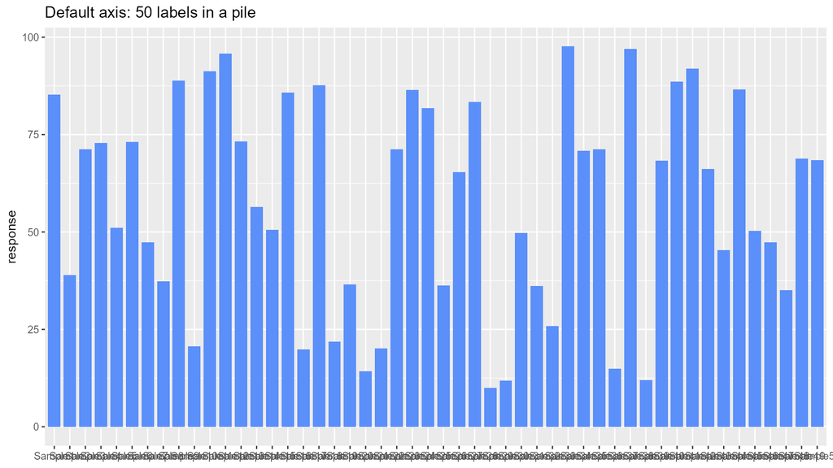

The default x axis with 50 discrete levels: the labels overlap and cannot be read

```r
ggplot(df50, aes(x = sample, y = value)) +
  geom_col(fill = "#5B8FF9", width = 0.8) +
  labs(x = NULL, y = "response", title = "Default axis: 50 labels in a pile") +
  theme_grey(base_size = 12)
```

`ggutils` provides `guide_axis_smart()`. It takes over label drawing on a discrete axis and does three things:

1. **Show only the labels you care about** (`which =` / `n =`). Every other tick is still connected to its meaning by a **leader line**, so the correspondence stays obvious.
2. **Spread the labels over several rows (x axis) or columns (y axis)** outside the axis, using the page space that a default axis wastes.
3. **Never overlap labels**: when there is not enough room it displays fewer labels instead of drawing a pile.

# Quick start

Add one `guides()` line to an existing plot:

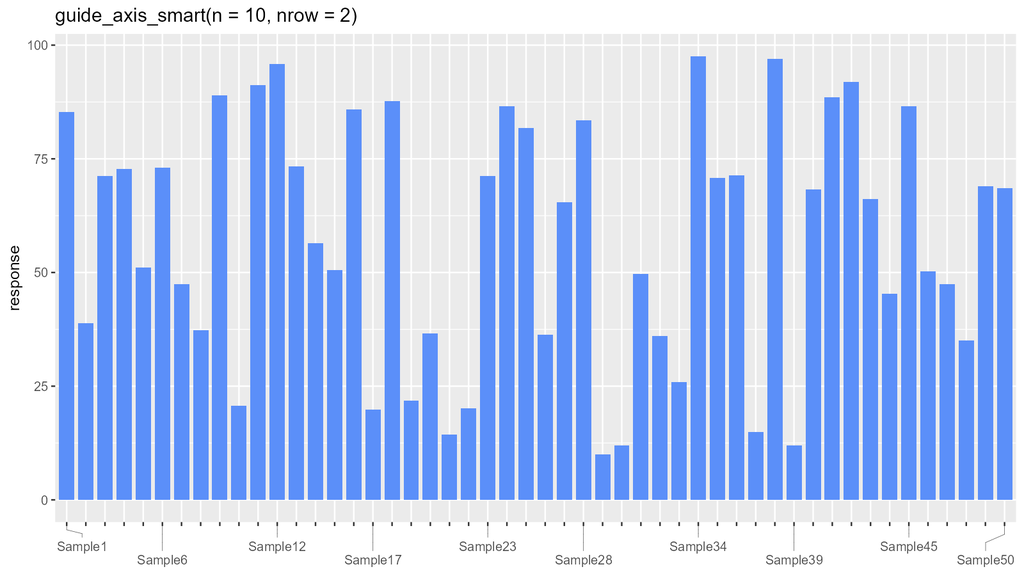

guide_axis_smart(n = 10, nrow = 2): only 10 labels, two staggered rows, each tied back to its tick

```r
ggplot(df50, aes(x = sample, y = value)) +
  geom_col(fill = "#5B8FF9", width = 0.8) +
  guides(x = guide_axis_smart(n = 10, nrow = 2)) +
  labs(x = NULL, y = "response", title = "guide_axis_smart(n = 10, nrow = 2)") +
  theme_grey(base_size = 12)
```

Only three things change: load the package, add `guides(x = guide_axis_smart(...))`, keep the rest. Note that you do **not** need `theme(axis.text.x = element_blank())` — the guide draws the labels itself.

## Two ways to attach the guide

`guide_axis_smart()` can go into `guides()` or into the `guide` argument of a scale (under `coord_flip()` the two are not equivalent, see below):

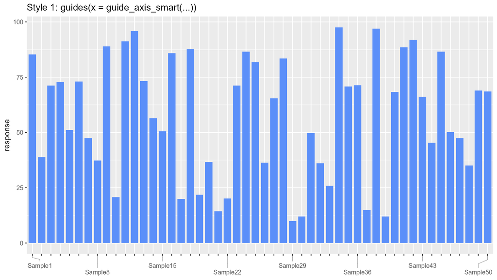

Both spellings give the same plot: guides(x = …) on top, scale_x_discrete(guide = …) below

```r
p_guides <- ggplot(df50, aes(x = sample, y = value)) +
  geom_col(fill = "#5B8FF9", width = 0.8) +
  guides(x = guide_axis_smart(n = 8, nrow = 2)) +
  labs(x = NULL, y = "response", title = "Style 1: guides(x = guide_axis_smart(...))") +
  theme_grey(base_size = 12)

p_scale <- ggplot(df50, aes(x = sample, y = value)) +
  geom_col(fill = "#5B8FF9", width = 0.8) +
  scale_x_discrete(guide = guide_axis_smart(n = 8, nrow = 2)) +
  labs(x = NULL, y = "response", title = "Style 2: scale_x_discrete(guide = ...)") +
  theme_grey(base_size = 12)

p_guides
```

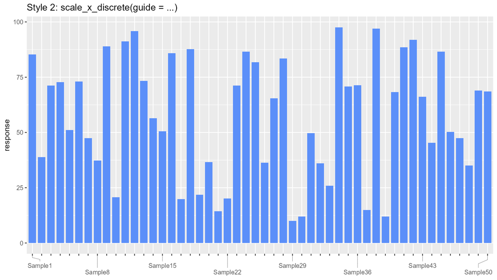

Both spellings give the same plot: guides(x = …) on top, scale_x_discrete(guide = …) below

```r
p_scale
```

# Parameter reference: what every argument does

The arguments fall into four groups: **which labels**, **how they are laid out**, **how the leader lines are drawn**, and **the rest, passed on to `guide_axis()`**. In practice you only touch five of them: `which`, `n`, `nrow`, `connection_style` and `angle`.

| Parameter | Default | Meaning |
| --- | --- | --- |
| **Which labels** |  |  |
| `which` | `NULL` | labels to show: integer indices / label text / logical vector / function. `NULL` shows as many as fit |
| `n` | `NULL` | maximum number of labels. With `which = NULL`, `n` evenly spaced labels are picked; with `which`, the selection is truncated to `n` |
| **Layout** |  |  |
| `nrow` | `NULL` | number of parallel tracks: rows on an x axis, columns on a y axis. `NULL` is automatic: one track while everything fits, more only when labels crowd together |
| `padding` | `0.25` | minimum gap between two label boxes in a track, as a fraction of the label height; on a radial axis it is the gap along the arc |
| `gap` | `0.30` | gap between two neighbouring tracks (relative to label height) |
| `extend` | `0` | how far a label may be pushed beyond the axis range (0 to 0.5). `0` keeps every label inside the panel; larger values need enough `plot.margin` |
| `panel_width` | `NULL` | panel width (x axis) or height (y axis) in cm, assumed when estimating the number of tracks; `NULL` estimates it from the device |
| `max_nrow` | `8L` | upper bound for the automatic number of tracks |
| **Leader lines** |  |  |
| `connection` | `TRUE` | draw leader lines? |
| `connection_style` | `"diagonal"` | `"diagonal"` (short stub, diagonal, short stub – the circlize / `anno_mark()` shape), `"straight"` (one line), `"elbow"` (perpendicular plus a shelf) |
| `link_length` | `3` | length in mm of the leader between the axis and the first track; on a radial axis, the distance between the circle and the label |
| `connection_col` | `NULL` | leader colour; `NULL` takes the tick colour |
| `connection_lwd` | `0.5` | leader width |
| `connection_lty` | `1` | leader line type |
| **Ticks and text** |  |  |
| `tick` | `"all"` | `"all"` ticks, `"shown"` only the ticks of drawn labels, `"none"` no ticks |
| `angle` | `NULL` | label rotation in degrees; `NULL` inherits the theme |
| `hjust`, `vjust` | `NULL` | label justification inside its box; `NULL` centres it, which keeps the leader on the visual centre of the text |
| **Radial only** |  |  |
| `theta_side` | `"outside"` | labels outside the circle (`"outside"`) or attached to the inner ring of `coord_radial(inner.radius =)` (`"inside"`) |
| **Passed to `guide_axis()`** |  |  |
| `title` | `waiver()` | axis title |
| `minor.ticks` | `FALSE` | draw minor ticks |
| `cap` | `"none"` | axis line end style |
| `order` | `0` | drawing order among guides |
| `position` | `waiver()` | axis position (top/bottom/left/right); rarely changed |
| `theme` | `NULL` | theme elements that apply to this guide only |

Four combinations that cover most plots:

```r
# 8 genes out of 200, one track
guides(y = guide_axis_smart(which = c("TP53", "EGFR", "MYC", "KRAS",
                                      "BRCA1", "PTEN", "RB1", "ALK")))

# 50 samples, at most 10 labels, staggered over two rows
guides(x = guide_axis_smart(n = 10, nrow = 2))

# long labels, crowded: extra tracks plus longer leader lines
guides(x = guide_axis_smart(which = 1:40, nrow = 3,
                            connection_style = "diagonal", link_length = 5))

# circular heatmap: labels outside the ring, 20 genes only
guides(theta = guide_axis_smart(which = mark, theta_side = "outside"))
```

# Show only the labels you want: four forms of `which`

`which` decides which labels are displayed. It accepts four forms:

| Form | Meaning | Example |
| --- | --- | --- |
| Integer vector | indices into the breaks of the scale | `which = seq(1, 50, by = 10)` |
| Character vector | exact match on the label text | `which = c("Sample1", "Sample25", "Sample50")` |
| Logical vector | one entry per label, `TRUE` keeps it | `which = grepl("0$", levels(sample))` |
| Function | `function(labels, positions)` returning a logical vector | `which = function(labels, positions) positions > 0.45 & positions < 0.55` |

`positions` is the **relative position** of a label inside the panel (0 to 1 along the axis). It does not depend on the data values and is handy for position-based rules.

## Integer indices

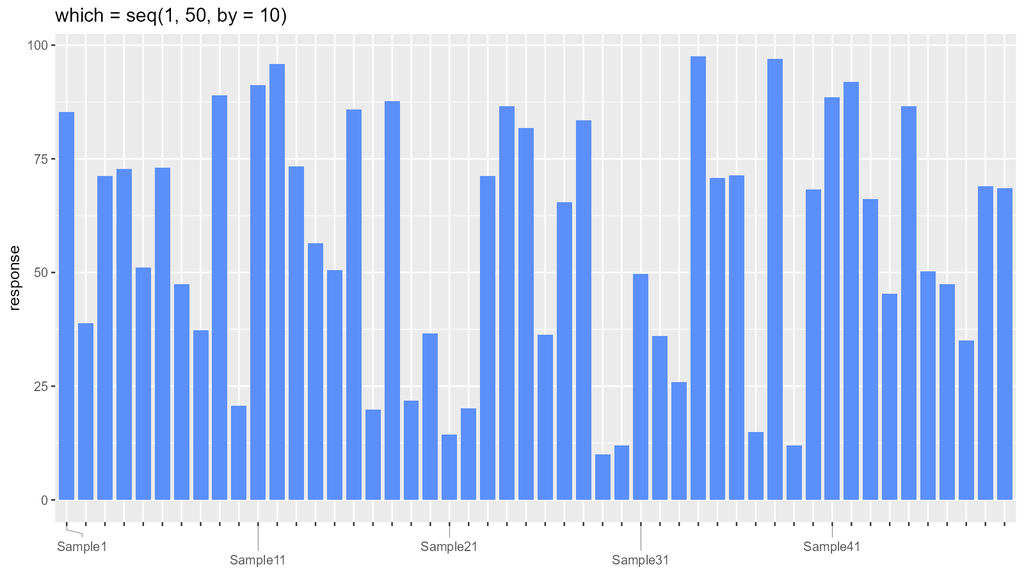

which = seq(1, 50, by = 10): every tenth label

```r
ggplot(df50, aes(x = sample, y = value)) +
  geom_col(fill = "#5B8FF9", width = 0.8) +
  guides(x = guide_axis_smart(which = seq(1, 50, by = 10), nrow = 2)) +
  labs(x = NULL, y = "response", title = "which = seq(1, 50, by = 10)") +
  theme_grey(base_size = 12)
```

## Character vector

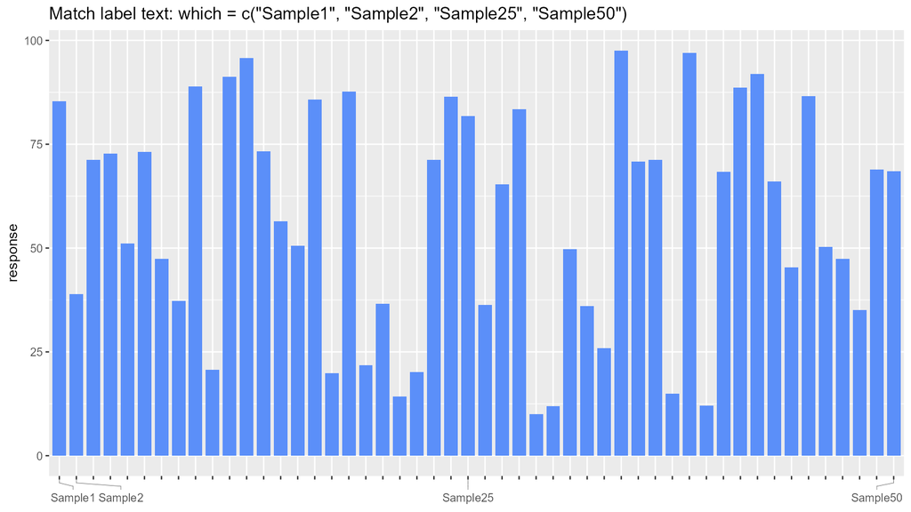

Matching label text: the four labels Sample1, Sample2, Sample25 and Sample50

```r
ggplot(df50, aes(x = sample, y = value)) +
  geom_col(fill = "#5B8FF9", width = 0.8) +
  guides(x = guide_axis_smart(
    which = c("Sample1", "Sample2", "Sample25", "Sample50"),
    nrow = 1
  )) +
  labs(x = NULL, y = "response", title = "Match label text: which = c(\"Sample1\", \"Sample2\", \"Sample25\", \"Sample50\")") +
  theme_grey(base_size = 12)
```

## Logical vector

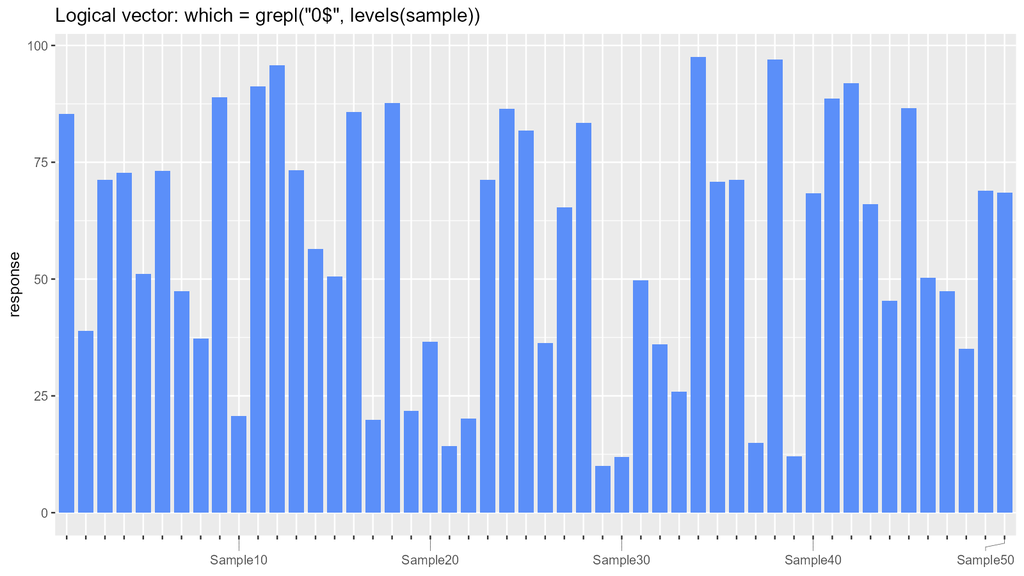

A logical vector: only samples whose number ends in 0

```r
ggplot(df50, aes(x = sample, y = value)) +
  geom_col(fill = "#5B8FF9", width = 0.8) +
  guides(x = guide_axis_smart(
    which = grepl("0$", levels(df50$sample)),
    nrow = 1
  )) +
  labs(x = NULL, y = "response", title = "Logical vector: which = grepl(\"0$\", levels(sample))") +
  theme_grey(base_size = 12)
```

## Function

When `which` is a function, it is called with the label texts and the relative positions and must return a logical vector (index vectors are also accepted). The example keeps every tenth label:

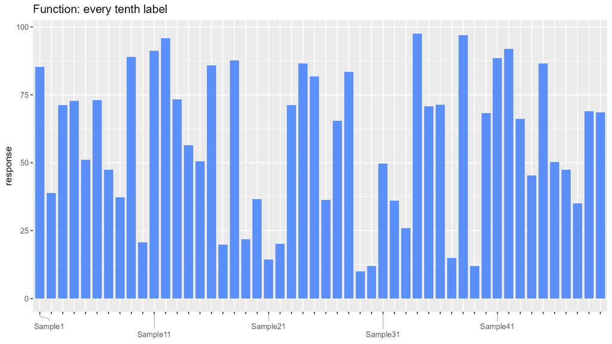

which = function(labels, positions) seq_along(labels) %% 10 == 1: every tenth label

```r
ggplot(df50, aes(x = sample, y = value)) +
  geom_col(fill = "#5B8FF9", width = 0.8) +
  guides(x = guide_axis_smart(
    which = function(labels, positions) seq_along(labels) %% 10 == 1,
    nrow = 2
  )) +
  labs(x = NULL, y = "response", title = "Function: every tenth label") +
  theme_grey(base_size = 12)
```

The function form is most useful for **position-based** selection: `positions` runs from 0 to 1, so `positions > 0.9` keeps only the right-hand end of the axis.

# Automatic selection: `n`

If you do not want to compute indices, just cap the number of labels:

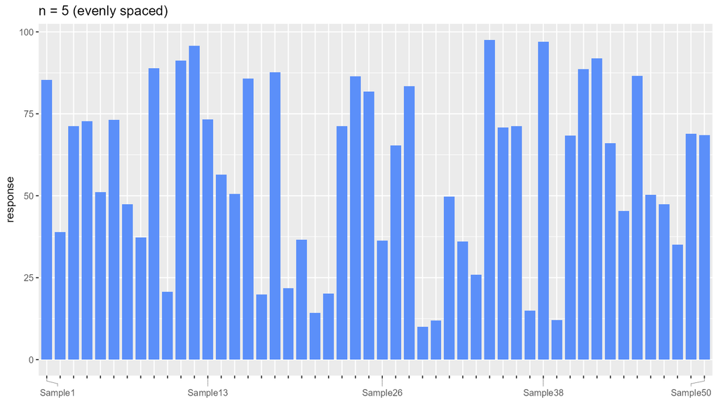

n = 5: five evenly spaced labels, one row is enough

```r
ggplot(df50, aes(x = sample, y = value)) +
  geom_col(fill = "#5B8FF9", width = 0.8) +
  guides(x = guide_axis_smart(n = 5)) +
  labs(x = NULL, y = "response", title = "n = 5 (evenly spaced)") +
  theme_grey(base_size = 12)
```

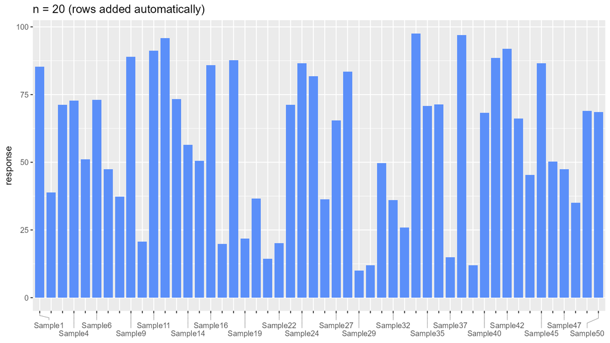

n = 20: 20 labels, split over two rows when one row is not enough

```r
ggplot(df50, aes(x = sample, y = value)) +
  geom_col(fill = "#5B8FF9", width = 0.8) +
  guides(x = guide_axis_smart(n = 20)) +
  labs(x = NULL, y = "response", title = "n = 20 (rows added automatically)") +
  theme_grey(base_size = 12)
```

When both `which` and `n` are given, `which` selects first and `n` then truncates the **result** to at most `n` labels, evenly spaced (`n` is a hard cap). With `which = NULL`, `n` picks evenly from all labels directly.

## Automatic behaviour: what happens when you pass nothing

**How the number of tracks (rows/columns) is chosen**: one row whenever the labels fit — they stretch along the axis, which gives short leader lines and the closest match to the `anno_mark()` look. More tracks are only added when the total width of the labels exceeds one row. If the labels crowd into a small stretch of the axis, the guide splits them over several rows even when their total width is small, using the span of that cluster, so that long crossing diagonals are avoided. At most `max_nrow` tracks (default `8`) are used.

With `which = NULL` and `n = NULL` the guide displays **all** labels by default. If the total width exceeds what `max_nrow` tracks can hold, the guide thins the labels out evenly and prints a **single** `cli` message, for example:

```
#> ℹ Only 88 of 200 labels fit into 8 tracks; 112 labels are not displayed.
#> ℹ Set `nrow` or `which` in `guide_axis_smart()` to control this.
```

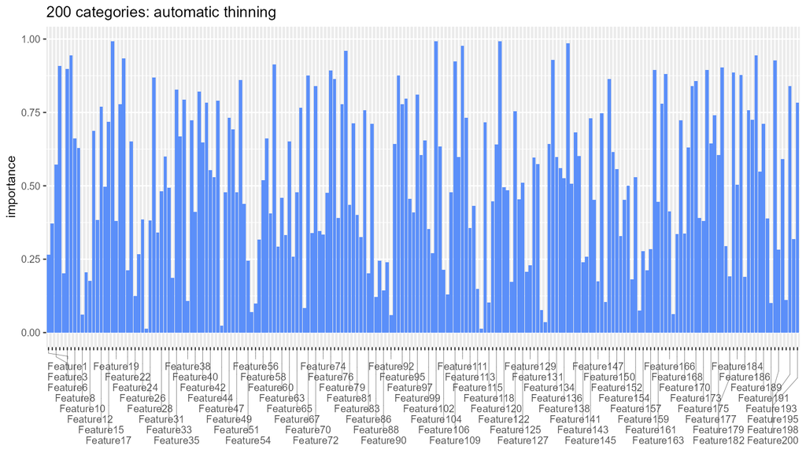

200 categories with neither which nor n: thinning keeps the plot readable, but fewer labels are shown

```r
set.seed(1)
df200 <- data.frame(
  feature = factor(paste0("Feature", 1:200), levels = paste0("Feature", 1:200)),
  value = runif(200)
)

ggplot(df200, aes(x = feature, y = value)) +
  geom_col(fill = "#5B8FF9", width = 0.9) +
  guides(x = guide_axis_smart()) +
  labs(x = NULL, y = "importance", title = "200 categories: automatic thinning") +
  theme_grey(base_size = 12)
```

To silence that message (for example when plotting in a loop), set `options(ggutils.quiet = TRUE)`. Still, **always prefer an explicit `n =` or `which =`** so that you decide which labels are shown, rather than the screen size.

# Staggering over rows: `nrow`, `gap`, `padding`

`nrow` controls how many rows the x axis labels occupy below the axis; `NULL` (the default) means automatic — **one row whenever it fits**, more rows only when the labels crowd or overflow. `gap` is the space between rows (default `0.30`) and `padding` the minimum space between neighbouring label boxes in one row (default `0.25`); both are **relative to the label height**.

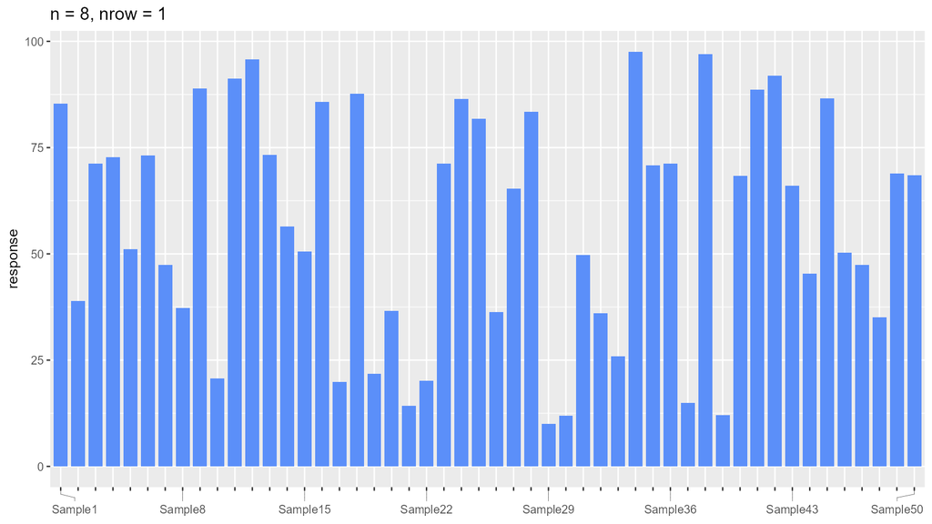

nrow = 1: everything in one row, the labels must fit

```r
ggplot(df50, aes(x = sample, y = value)) +
  geom_col(fill = "#5B8FF9", width = 0.8) +
  guides(x = guide_axis_smart(n = 8, nrow = 1)) +
  labs(x = NULL, y = "response", title = "n = 8, nrow = 1") +
  theme_grey(base_size = 12)
```

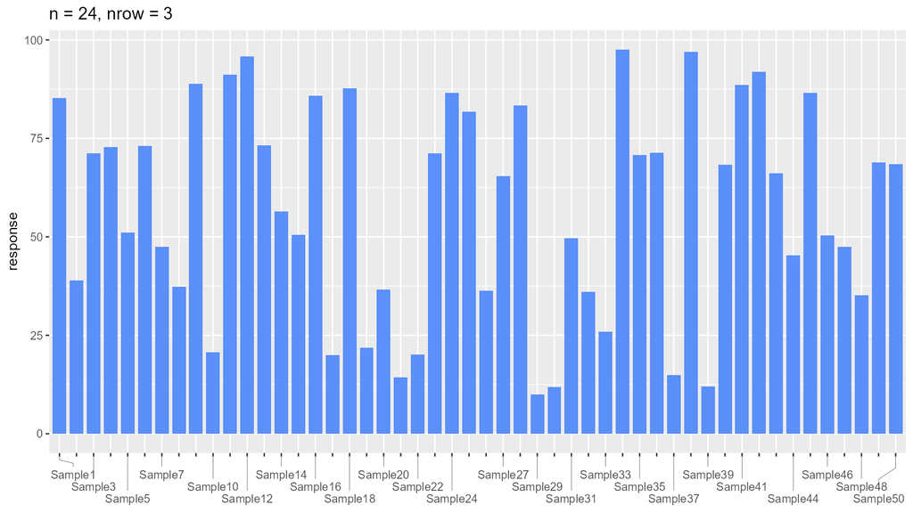

nrow = 3: three staggered rows; more vertical space means more labels

```r
ggplot(df50, aes(x = sample, y = value)) +
  geom_col(fill = "#5B8FF9", width = 0.8) +
  guides(x = guide_axis_smart(n = 24, nrow = 3)) +
  labs(x = NULL, y = "response", title = "n = 24, nrow = 3") +
  theme_grey(base_size = 12)
```

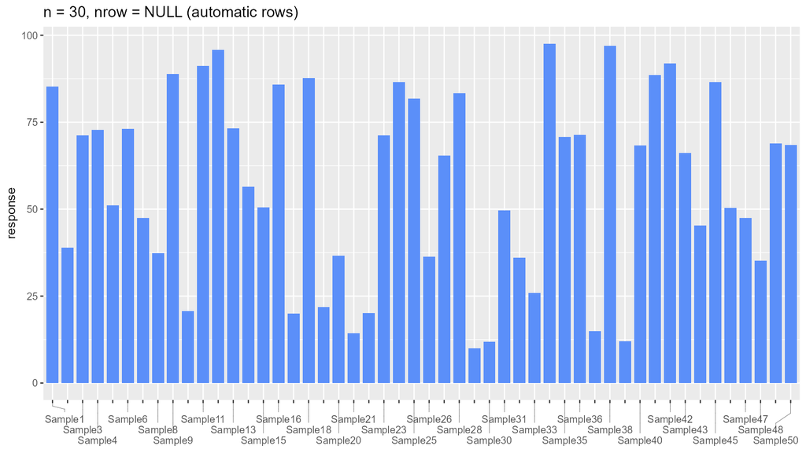

nrow = NULL: one row when it fits, otherwise rows are added automatically

```r
ggplot(df50, aes(x = sample, y = value)) +
  geom_col(fill = "#5B8FF9", width = 0.8) +
  guides(x = guide_axis_smart(n = 30)) +
  labs(x = NULL, y = "response", title = "n = 30, nrow = NULL (automatic rows)") +
  theme_grey(base_size = 12)
```

Rules of thumb:

- **Want more labels**: increase `nrow` (columns on a y axis, see below);
- **Rows look cramped**: increase `gap` and `padding` (e.g. `gap = 0.4`);
- **Labels clipped at the canvas edge**: `extend = 0` (the default) keeps every label box inside the panel, so this should not happen; only if you increase `extend` (to buy more layout freedom) do you also need a matching `theme(plot.margin = ...)`.

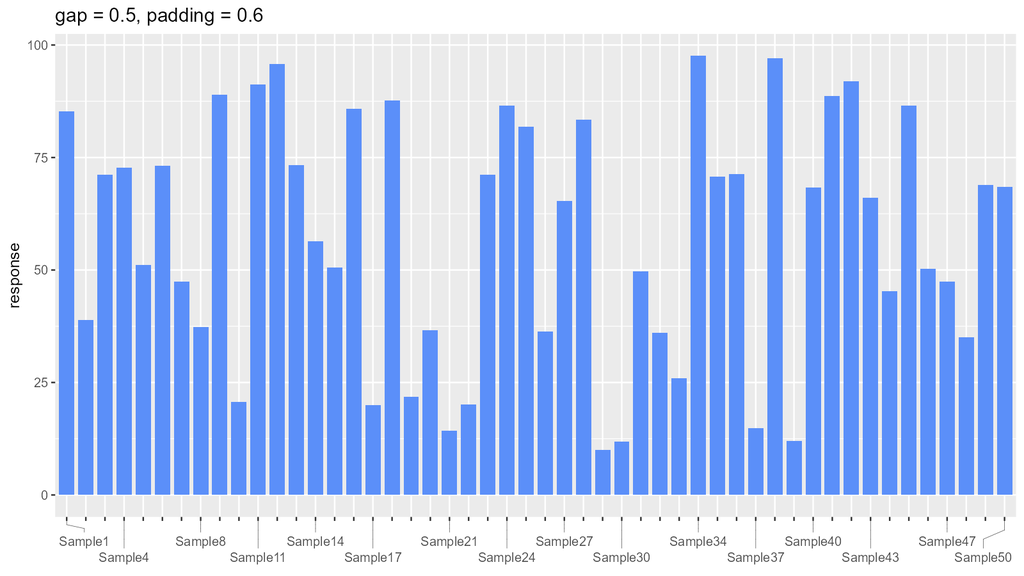

gap = 0.5, padding = 0.6: more space between rows and boxes

```r
ggplot(df50, aes(x = sample, y = value)) +
  geom_col(fill = "#5B8FF9", width = 0.8) +
  guides(x = guide_axis_smart(n = 16, nrow = 2, gap = 0.5, padding = 0.6)) +
  labs(x = NULL, y = "response", title = "gap = 0.5, padding = 0.6") +
  theme_grey(base_size = 12)
```

# Leader lines: `connection_style` and `link_length`

Whenever a label is **moved** (its position differs from its tick) the guide draws a leader line by default (`connection = TRUE`). There are three styles:

- `"diagonal"` (default): a short segment perpendicular to the axis, then a diagonal to the label’s row, then another short perpendicular segment. This is the classic geometry of `circlize` and `ComplexHeatmap::anno_mark()` and stays readable with several rows;
- `"straight"`: one straight diagonal from the tick to the label box;
- `"elbow"`: a perpendicular segment followed by a shelf parallel to the axis.

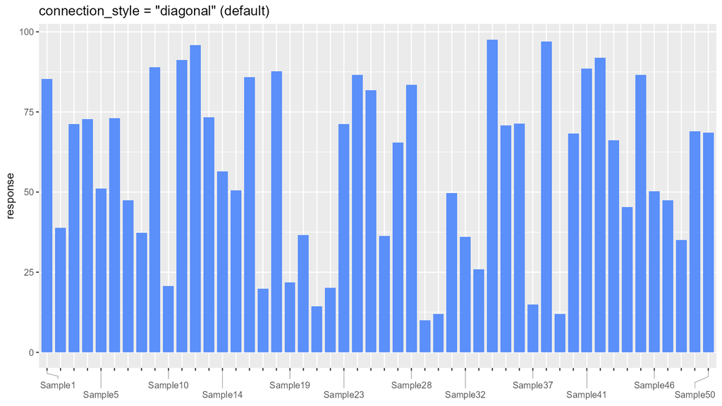

connection_style = ‘diagonal’ (default): short stub + diagonal + short stub

```r
ggplot(df50, aes(x = sample, y = value)) +
  geom_col(fill = "#5B8FF9", width = 0.8) +
  guides(x = guide_axis_smart(n = 12, nrow = 2)) +
  labs(x = NULL, y = "response", title = "connection_style = \"diagonal\" (default)") +
  theme_grey(base_size = 12)
```

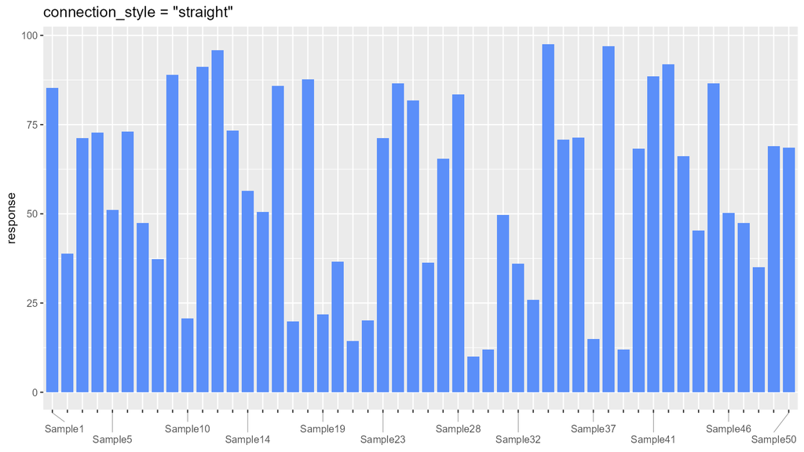

connection_style = ‘straight’: a single diagonal

```r
ggplot(df50, aes(x = sample, y = value)) +
  geom_col(fill = "#5B8FF9", width = 0.8) +
  guides(x = guide_axis_smart(n = 12, nrow = 2, connection_style = "straight")) +
  labs(x = NULL, y = "response", title = "connection_style = \"straight\"") +
  theme_grey(base_size = 12)
```

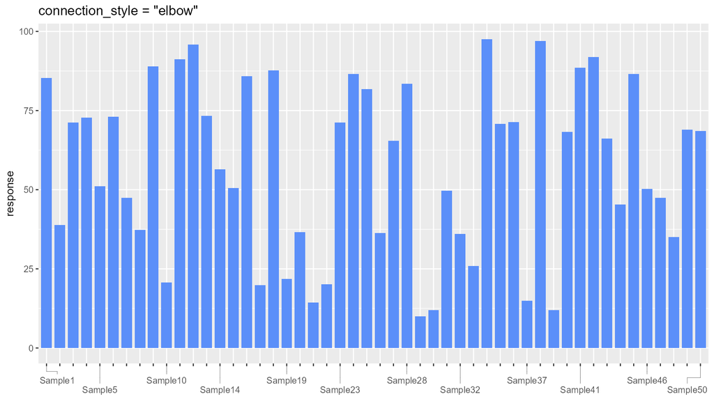

connection_style = ‘elbow’: a perpendicular segment plus a shelf

```r
ggplot(df50, aes(x = sample, y = value)) +
  geom_col(fill = "#5B8FF9", width = 0.8) +
  guides(x = guide_axis_smart(n = 12, nrow = 2, connection_style = "elbow")) +
  labs(x = NULL, y = "response", title = "connection_style = \"elbow\"") +
  theme_grey(base_size = 12)
```

`link_length` (default `3`, in millimetres) controls the length of the leader segment between the axis and the first row (column) of labels: decrease it when there are many rows and the lines get dense, increase it for roomier leader lines.

Colour, width and linetype of the lines are controlled by `connection_col`, `connection_lwd` (default `0.5`) and `connection_lty`; with `connection_col = NULL` (the default) the ticks’ colour is used. Set `connection = FALSE` to turn leader lines off.

## Ticks: `tick`

`tick` controls the short tick marks next to the axis line:

- `"all"` (default): draw every tick, keeping the information that there are more categories;
- `"shown"`: only draw ticks for the labels that are displayed, a cleaner look;
- `"none"`: no ticks at all.

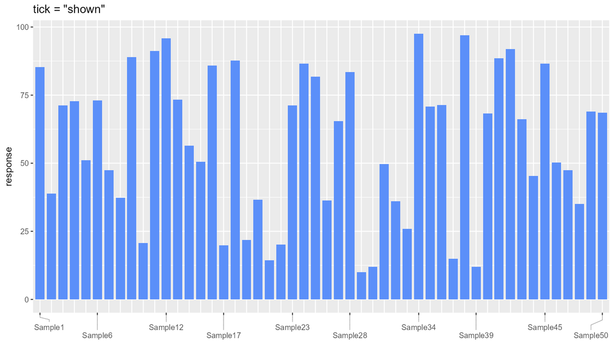

tick = ‘shown’: ticks only for the displayed labels

```r
ggplot(df50, aes(x = sample, y = value)) +
  geom_col(fill = "#5B8FF9", width = 0.8) +
  guides(x = guide_axis_smart(n = 10, nrow = 2, tick = "shown")) +
  labs(x = NULL, y = "response", title = "tick = \"shown\"") +
  theme_grey(base_size = 12)
```

# y axis (vertical discrete axis)

Map the discrete variable to the y axis. Note that **`nrow` means columns on a y axis**: the labels are spread over several columns outside the axis, and the outermost column holds the labels that are pushed furthest out.

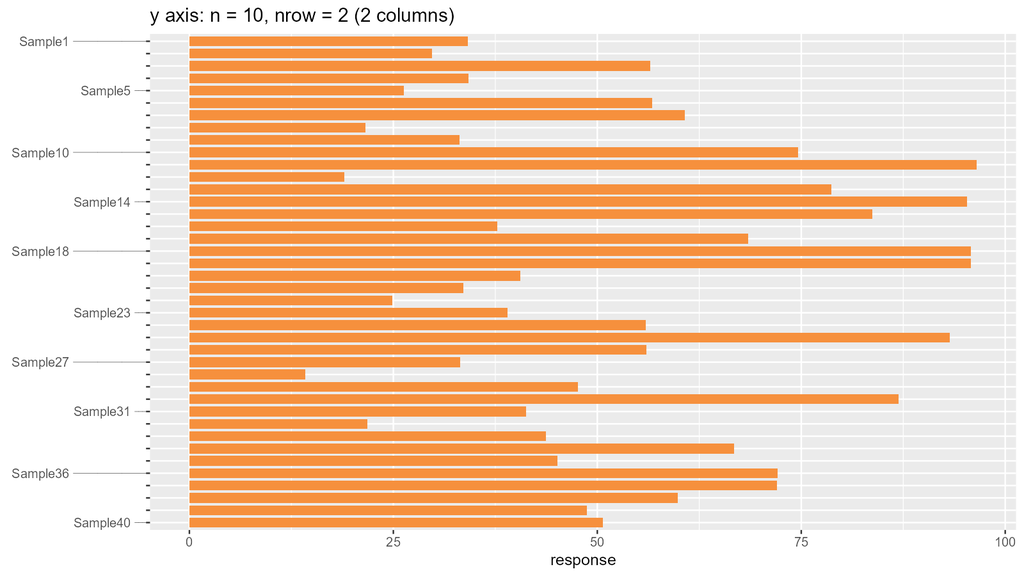

y axis: nrow = 2 spreads the labels over 2 columns

```r
labs40 <- paste0("Sample", 1:40)
df40 <- data.frame(
  sample = factor(labs40, levels = rev(labs40)),
  value = round(runif(40, 10, 100), 1)
)

ggplot(df40, aes(x = value, y = sample)) +
  geom_col(fill = "#F6903D", width = 0.8) +
  guides(y = guide_axis_smart(n = 10, nrow = 2)) +
  labs(x = "response", y = NULL, title = "y axis: n = 10, nrow = 2 (2 columns)") +
  theme_grey(base_size = 12)
```

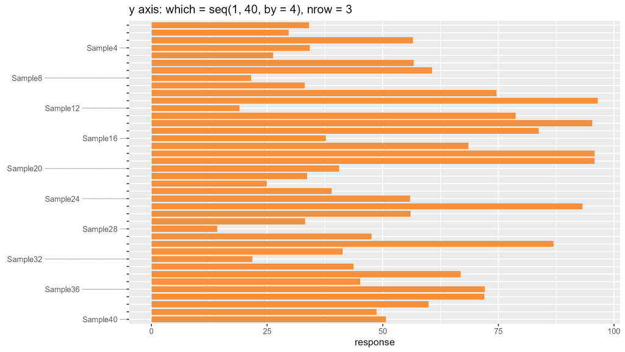

y axis: nrow = 3, three columns make room for more labels

```r
ggplot(df40, aes(x = value, y = sample)) +
  geom_col(fill = "#F6903D", width = 0.8) +
  guides(y = guide_axis_smart(which = seq(1, 40, by = 4), nrow = 3)) +
  labs(x = "response", y = NULL, title = "y axis: which = seq(1, 40, by = 4), nrow = 3") +
  theme_grey(base_size = 12)
```

# Radial coordinates: `coord_radial()`

`coord_radial()` renames the position scales to `theta` and `r`, so the guide is attached with `guides(theta = ...)`. On this axis `ggutils` lays the labels out the way `circlize::circos.labels()` does: the text runs along the radius and points towards the centre of the circle (turned around on the left half), crowded labels are spread along the arc with the `smartAlign` algorithm, and every label is tied to its tick by a three-segment leader line (radial stub, diagonal, radial stub).

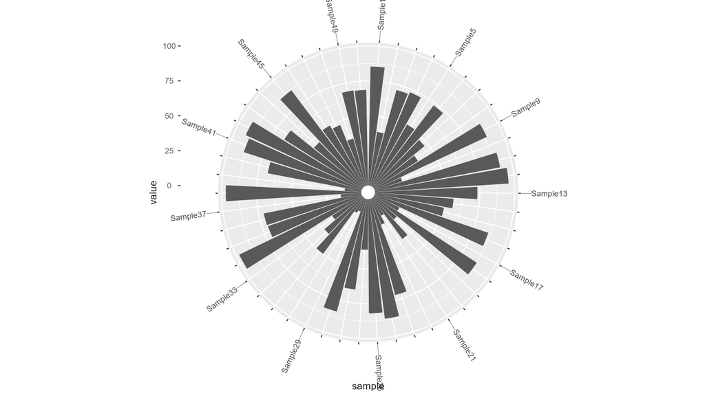

coord_radial(theta = ‘x’): a circular bar chart, every 4th label

```r
ggplot(df50, aes(sample, value)) +
  geom_col() +
  coord_radial(theta = "x") +
  guides(theta = guide_axis_smart(which = seq(1, 50, by = 4)))
```

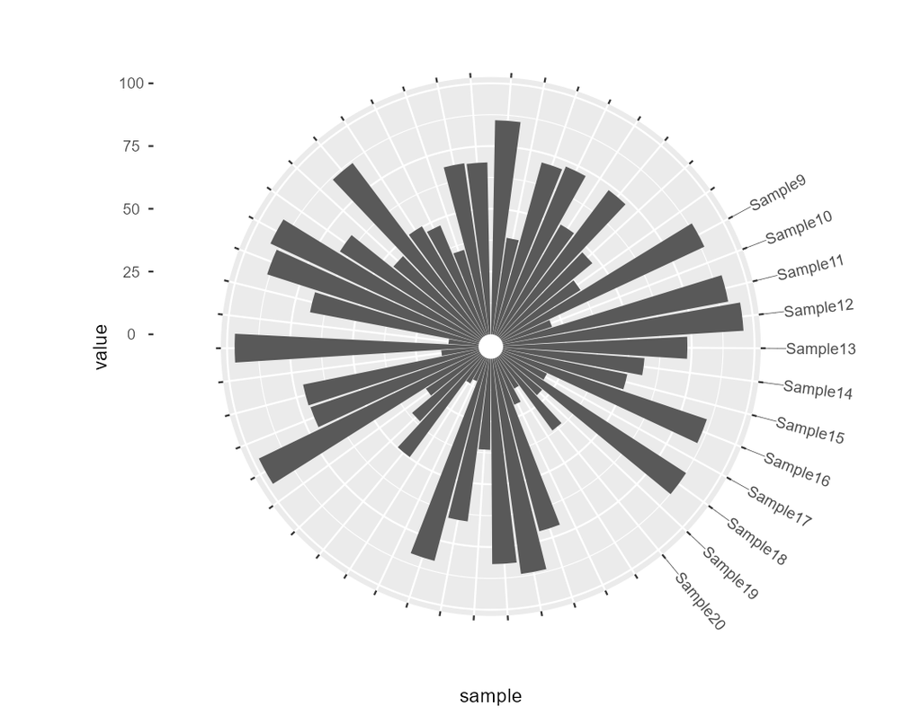

12 crowded labels: spread along the arc and connected with three-segment leader lines

```r
ggplot(df50, aes(sample, value)) +
  geom_col() +
  coord_radial(theta = "x") +
  guides(theta = guide_axis_smart(which = 9:20))
```

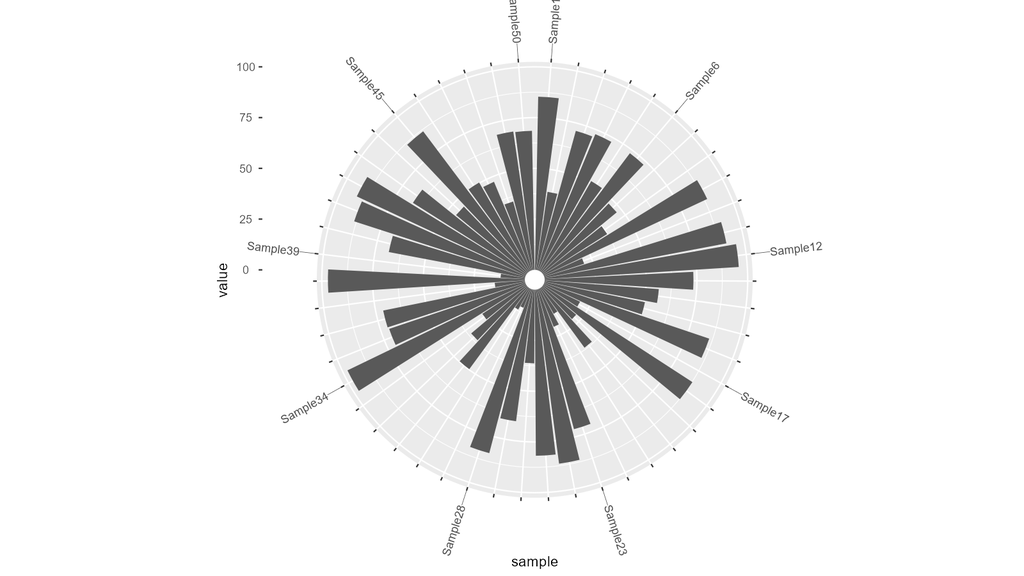

categories mapped to y with theta = ‘y’ work the same way

```r
ggplot(df50, aes(value, sample)) +
  geom_col() +
  coord_radial(theta = "y") +
  guides(theta = guide_axis_smart(n = 10))
```

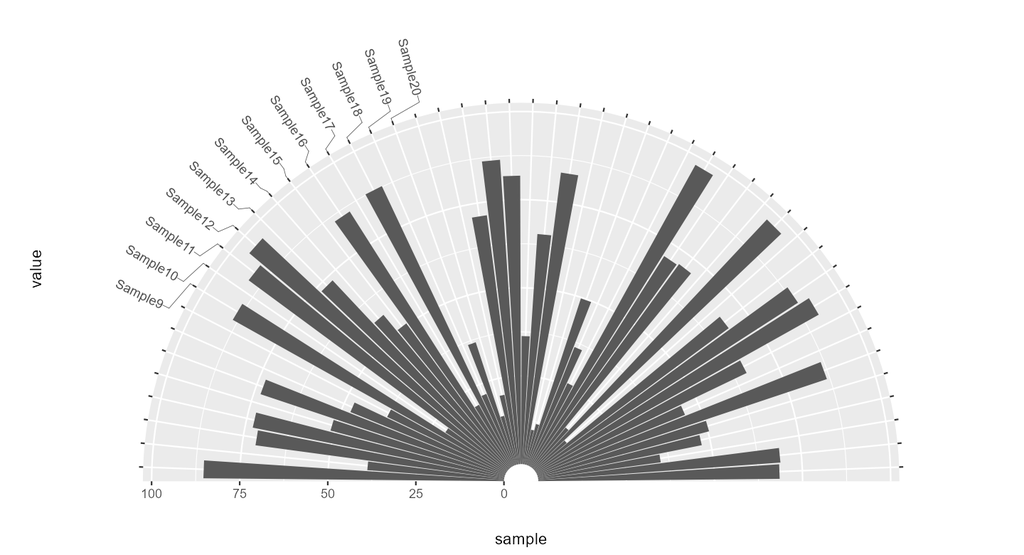

a half circle (start/end) is laid out the same way

```r
ggplot(df50, aes(sample, value)) +
  geom_col() +
  coord_radial(theta = "x", start = -0.5 * pi, end = 0.5 * pi) +
  guides(theta = guide_axis_smart(which = 9:20))
```

## Circular heatmaps: labels outside or inside

With the bundled data (300 genes x 8 samples) the `theta` axis is the gene axis:

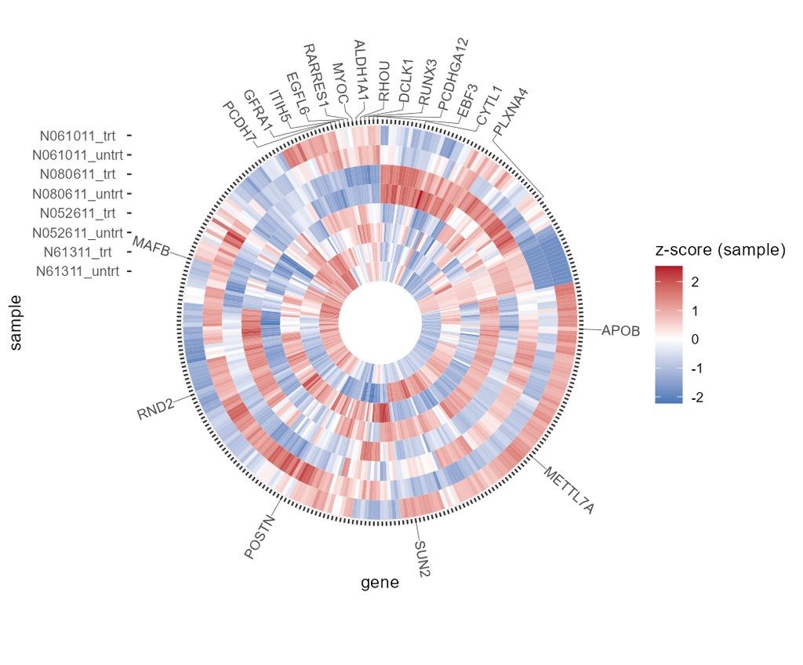

circular heatmap with the labels outside: the crowded gene cluster spreads along the outer arc

```r
data(airway_heatmap)
ggplot(airway_sample_z, aes(gene, sample, fill = z_sample)) +
  geom_tile() +
  coord_radial(theta = "x", inner.radius = 0.2) +
  guides(theta = guide_axis_smart(which = airway_heatmap$mark)) +
  scale_fill_gradient2(low = "#2166ac", mid = "white", high = "#b2182b",
                       midpoint = 0, name = "z-score (sample)")
```

With a large inner radius the labels can go inside the hole (`theta_side = "inside"`), attached to the inner radius:

```
#> Only 18 of 20 labels fit around the ring; 2 were dropped. Use `which` / `n` or
#> a larger device.
```

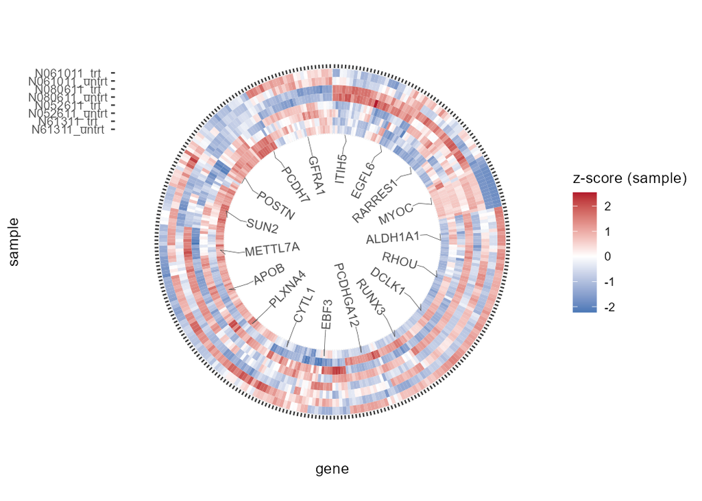

circular heatmap with the labels inside: theta_side = ‘inside’, attached to the inner radius

```r
ggplot(airway_sample_z, aes(gene, sample, fill = z_sample)) +
  geom_tile() +
  coord_radial(theta = "x", inner.radius = 0.62) +
  guides(theta = guide_axis_smart(
    which = airway_heatmap$mark, theta_side = "inside"
  )) +
  scale_fill_gradient2(low = "#2166ac", mid = "white", high = "#b2182b",
                       midpoint = 0, name = "z-score (sample)")
```

## Facets: one circle per panel

With `facet_wrap()` / `facet_grid()` every panel is its own circle and lays its labels out independently:

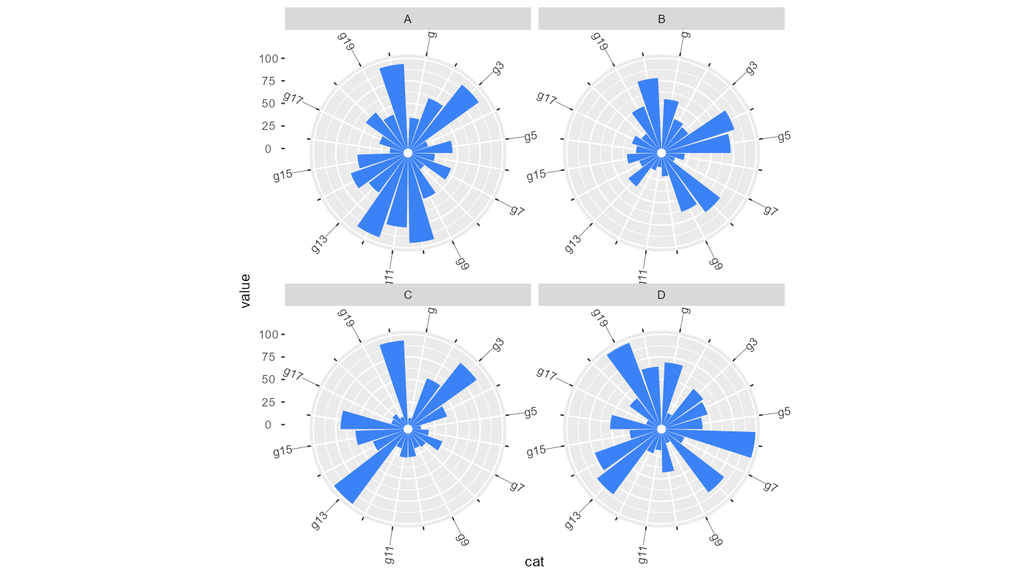

facet_wrap + coord_radial: one circle per panel, every 2nd label

```r
d_facet <- data.frame(
  panel = rep(c("A", "B", "C", "D"), each = 20),
  cat   = factor(rep(paste0("g", 1:20), 4), levels = paste0("g", 1:20)),
  value = round(runif(80, 5, 100), 1)
)
ggplot(d_facet, aes(cat, value)) +
  geom_col(fill = "#3b82f6") +
  coord_radial(theta = "x") +
  guides(theta = guide_axis_smart(which = seq(1, 20, by = 2))) +
  facet_wrap(~panel)
```

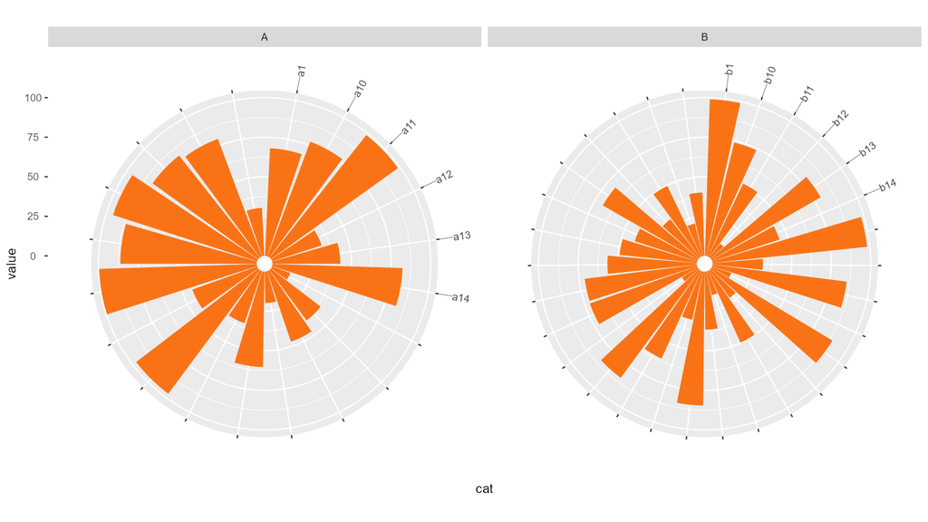

facet_wrap + free_x: each panel labels its own first 6 categories

```r
d_free <- data.frame(
  panel = c(rep("A", 20), rep("B", 30)),
  cat   = factor(c(paste0("a", 1:20), paste0("b", 1:30))),
  value = round(runif(50, 5, 100), 1)
)
ggplot(d_free, aes(cat, value)) +
  geom_col(fill = "#f97316") +
  coord_radial(theta = "x") +
  guides(theta = guide_axis_smart(which = 1:6)) +
  facet_wrap(~panel, scales = "free_x")
```

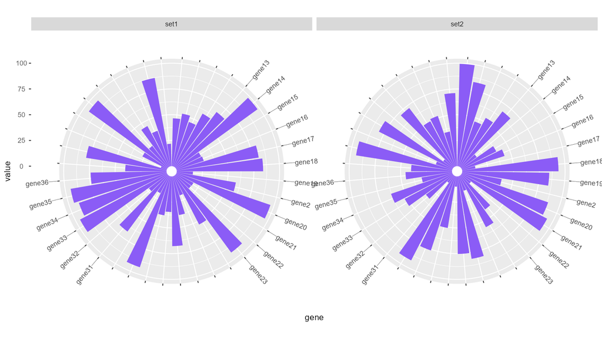

a crowded cluster in every panel: spread independently per panel

```r
d_crowd <- data.frame(
  panel = rep(c("set1", "set2"), each = 40),
  gene  = factor(rep(paste0("gene", 1:40), 2)),
  value = round(runif(80, 5, 100), 1)
)
ggplot(d_crowd, aes(gene, value)) +
  geom_col(fill = "#8b5cf6") +
  coord_radial(theta = "x") +
  guides(theta = guide_axis_smart(which = c(5:16, 25:30))) +
  facet_wrap(~panel)
```

For a faceted circular heatmap add `scales = "free_x"`: each panel then uses its own gene scale, so the ring is complete and the labels only land on the genes that panel actually contains:

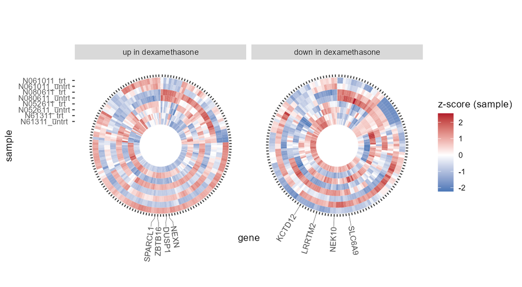

faceted circular heatmap + free_x: complete rings, each panel labels its own 4 genes

```r
ggplot(airway_sample_z, aes(gene, sample, fill = z_sample)) +
  geom_tile() +
  coord_radial(theta = "x", inner.radius = 0.3) +
  guides(theta = guide_axis_smart(which = unlist(airway_heatmap$mark_by_set))) +
  facet_wrap(~gene_set, ncol = 2, scales = "free_x") +
  scale_fill_gradient2(low = "#2166ac", mid = "white", high = "#b2182b",
                       midpoint = 0, name = "z-score (sample)")
```

> Without `scales = "free_x"` the panels share one `theta` scale: half of each ring stays empty and the 8 genes picked by `which` are labelled in both panels.

Radial labels inherit the theme’s axis text style (`axis.text.x` / `axis.text.y`: size, colour, family, …) exactly like the stock axis labels.